# Chapter 16

Julin Maloof

8/3/2020

## Problems

```r
library(rethinking)
library(tidyverse)
```

### 16M1

*Modify the cylinder height model, m16.1, so that the exponent 3 on height is instead a free parameter. Do you recover the value of 3 or not? Plot the posterior predictions for the new model. How do they differ from those of m16.1?*

Data and original model

```r
data(Howell1)
d <- Howell1

# scale observed variables
d$w <- d$weight / mean(d$weight)
d$h <- d$height / mean(d$height)

## R code 16.2
m16.1 <- ulam(
    alist(
        w ~ dlnorm( mu , sigma ),
        exp(mu) <- 3.141593 * k * p^2 * h^3,
        p ~ beta( 2 , 18 ),
        k ~ exponential( 0.5 ),
        sigma ~ exponential( 1 )
    ), data=d , chains=4 , cores=4 )
```

plot some exp distributions

```r
x <- seq(0,10,.1)
plotd <- tibble(rate=seq(0.1,1.1,.2)) %>%
    mutate(dist=map(rate, ~ data.frame(x=x,y=dexp(x, rate=.)))) %>%
    unnest()

plotd
plotd %>% ggplot(aes(x=x,y=y, group=rate, color=as.factor(rate))) +
    geom_line()
```

Plot some gamma distributions:

```r
x <- seq(0,10,.1)
plotd <- tibble(shape=seq(1,10,2)) %>%
    mutate(dist=map(shape, ~ data.frame(x=x,
                                        y=dgamma(x, shape=., rate=1)))) %>%
    unnest()

plotd
plotd %>% ggplot(aes(x=x,y=y, group=shape, color=as.factor(shape))) +
    geom_line()
```

```r
x <- seq(0,10,.1)
plotd <- tibble(shape=seq(1,10,2)) %>%
    mutate(dist=map(shape, ~ data.frame(x=x,
                                        y=dgamma(x, shape=., rate=2)))) %>%
    unnest()

plotd
plotd %>% ggplot(aes(x=x,y=y, group=shape, color=as.factor(shape))) +
    geom_line()
```

rethinking does weird change to gamma dist:

```r
## R code 16.2
m16m1 <- ulam(
    alist(
        w ~ dlnorm( mu , sigma ),
        exp(mu) <- 3.141593 * k * p^2 * h^a,
        a ~ gamma(7, .5),
        p ~ beta( 2 , 18 ),
        k ~ exponential( 0.5 ),
        sigma ~ exponential( 1 )
    ), data=d , chains=4 , cores=4 )
stancode(m16m1)
```

```r
## R code 16.2
m16m1.alt <- ulam(
    alist(
        w ~ dlnorm( mu , sigma ),
        exp(mu) <- 3.141593 * k * p^2 * h^a,
        a ~ exponential(0.3),
        p ~ beta( 2 , 18 ),
        k ~ exponential( 0.5 ),
        sigma ~ exponential( 1 )
    ), data=d , chains=4 , cores=4 )
```

```r
precis(m16.1)
```

```r
precis(m16m1)
```

```r
precis(m16m1.alt)
```

Plot

```r
## R code 16.3
h_seq <- seq( from=0 , to=max(d$h) , length.out=30 )
w_sim <- sim( m16.1 , data=list(h=h_seq) )
mu_mean <- apply( w_sim , 2 , mean )
w_CI <- apply( w_sim , 2 , PI )
plot( d$h , d$w , xlim=c(0,max(d$h)) , ylim=c(0,max(d$w)) , col=rangi2 ,
      lwd=2 , xlab="height (scaled)" , ylab="weight (scaled)" )
lines( h_seq , mu_mean )
shade( w_CI , h_seq )

## plus estimate from new model
w_sim2 <- sim( m16m1.alt , data=list(h=h_seq) )
mu_mean2 <- apply( w_sim2 , 2 , mean )
w_CI2 <- apply( w_sim2 , 2 , PI )
lines( h_seq , mu_mean2, lty=2 )
shade( w_CI2 , h_seq, col=col.alpha("yellow",
                                    0.25) )
```

This does a better job on the tails, maybe less good in the middle? Real problem is that it looks to me like there is a mixed distribution here.

### 16M2

*Conduct a prior predictive simulation for the cylinder height model. Begin with the priors in the chapter. Do these produce reasonable prior height distributions? If not, which modifications do you suggest?*

Data and original model

```r
data(Howell1)
d <- Howell1

# scale observed variables
d$w <- d$weight / mean(d$weight)
d$h <- d$height / mean(d$height)

## R code 16.2
m16.1 <- ulam(
    alist(
        w ~ dlnorm( mu , sigma ),
        exp(mu) <- 3.141593 * k * p^2 * h^3,
        p ~ beta( 2 , 18 ),
        k ~ exponential( 0.5 ),
        sigma ~ exponential( 1 )
    ), data=d , chains=4 , cores=4 )
```

Trying to understand the scaling

```r
post <- as.data.frame(extract.samples(m16.1))
str(post)
post <- post %>% mutate(mu=log(pi*k*p^2*1^3))
head(post)
```

nope

```r
post <- as.data.frame(extract.samples(m16.1))
str(post)
post <- post %>% mutate(mu=pi*k*p^2*1^3)
head(post)
```

yep

so why not remove exp and make it normally distributed?

```r
m16.1.norm <- ulam(
    alist(
        w ~ dnorm( mu , sigma ),
        mu <- 3.141593 * k * p^2 * h^3,
        p ~ beta( 2 , 18 ),
        k ~ exponential( 0.5 ),
        sigma ~ exponential( 1 )
    ), data=d , chains=4 , cores=4 )

precis(m16.1.norm)
```

Does not sample as well but more or less works.

back to the prior:

100 draws from the prior

```r
prior1 <- tibble(
    i=1:100,
    p=rbeta(100, 2, 18),
    k=rexp(100, .5)
)
prior1
```

draw a curve for each of these 100:

```r
prior1 %>% group_by(i) %>%
    mutate(results=map2(p,k, function(p,k) {
        tibble(h=h_seq,
               w=pi * k * p^2 * h_seq^3)})) %>%
    unnest() %>%
    ggplot(aes(x=h,y=w)) +
    geom_line(aes(group=i), alpha=.2) +
    geom_point(data = d, shape=1, alpha=.5, color="blue")
```

Not so good!

Try again:

```r
tibble(
    i=1:100,
    p=rbeta(100, 5, 10),
    k=rexp(100, .5)
) %>% group_by(i) %>%
    mutate(results=map2(p,k, function(p,k) {
        tibble(h=h_seq,
               w=pi * k * p^2 * h_seq^3)})) %>%
    unnest() %>%
    ggplot(aes(x=h,y=w)) +
    geom_line(aes(group=i), alpha=.2) +
    geom_point(data = d, shape=1, alpha=.5, color="blue")
```

Plot old and new prior for p

```r
x <- seq(0,1,.01)
d <- tibble(shape1=c(2,5),shape2=c(18,10),prior=c("old", "new")) %>%
    mutate(dist=map2(shape1, shape2,
                     ~ data.frame(
                         x=x,
                         y=dbeta(x, shape1=.x, shape2 = .y)))) %>%
    unnest()

d %>% ggplot(aes(x=x,y=y, group=prior, color=as.factor(prior))) +
    geom_line()
```

### 16M3

*Use prior predictive simulations to investigate the Lynx-hare model. Begin with the priors in the chapter. Which population dynamics do these produce? Can you suggest any improvements to the priors, on the basis of your simulations?*

```r
data(Lynx_Hare)
```

Priors from the stan model

```r
// priors
  theta[{1,3}] ~ normal( 1 , 0.5 );    // bh,ml
  theta[{2,4}] ~ normal( 0.05, 0.05 ); // mh,bl
  sigma ~ exponential( 1 );
  pop_init ~ lognormal( log(10) , 1 );
  p ~ beta(40,200);
  // observation model
  // connect latent population state to observed pelts
  for ( t in 1:N )
    for ( k in 1:2 )
      pelts[t,k] ~ lognormal( log(pop[t,k]*p[k]) , sigma[k] );
}
generated quantities {
  real pelts_pred[N,2];
  for ( t in 1:N )
    for ( k in 1:2 )
      pelts_pred[t,k] = lognormal_rng( log(pop[t,k]*p[k]) , sigma[k] );
```

I think we want to give the simulation code initial populations and have it predict observed over time

update simulation code (note that order of theta is different here than in the stan code)

```r
sim_lynx_hare <- function( n_steps=1e4 , init , theta , sigma, p, dt=0.002 ) {
    L <- rep(NA,n_steps)
    H <- rep(NA,n_steps)
    Lobs <- rep(NA, n_steps)
    Hobs <- rep(NA, n_steps)
    L[1] <- init[1]
    H[1] <- init[2]
    Lobs[1] <- rlnorm(1, ifelse(p[1]*L[1] < 0, 0, log(p[1]*L[1])), sigma[1])
    Hobs[1] <- rlnorm(1, ifelse(p[2]*H[1] < 0, 0, log(p[2]*H[1])), sigma[2])
    for ( i in 2:n_steps ) {
        H[i] <- H[i-1] + dt*H[i-1]*( theta[1] - theta[2]*L[i-1] )
        L[i] <- L[i-1] + dt*L[i-1]*( theta[3]*H[i-1] - theta[4] )
        Lobs[i] <- rlnorm(1, ifelse(p[1]*L[i] < 0, 0, log(p[1]*L[i])), sigma[1])
        Hobs[i] <- rlnorm(1, ifelse(p[2]*H[i] < 0, 0, log(p[2]*H[i])), sigma[2])
    }
    return( tibble(L_pop=L,H_pop=H,L_obs=Lobs,H_obs=Hobs,step=1:n_steps) )
}
```

```r
init <- c(12.12, 3.81)
p <- c(0.174, 0.127)
sigma <- c(0.705, 1.74)
theta <- c(1.323, 0, 0.104, 0.299)
```

For one run through

```r
init <- rlnorm(2, log(10), 1)
theta <- rnorm(4, c(1, 0.05, 0.05, 1), c(.5, .05, .05, .5)) #bh, mh, bl, ml
theta <- ifelse(theta<0,0,theta)
sigma <- rexp(2,1)
p <- rbeta(2, 40, 200)
z <- sim_lynx_hare( 1e4 , init , theta, sigma, p ) %>% select(1:4) %>% as.matrix()

plot( z[,4] , type="l" , ylim=c(0,max(z[,4])) , lwd=2 , xaxt="n" ,
      ylab="observed number (thousands)" , xlab="" )
lines( z[,3] , col=rangi2 , lwd=2 )
```

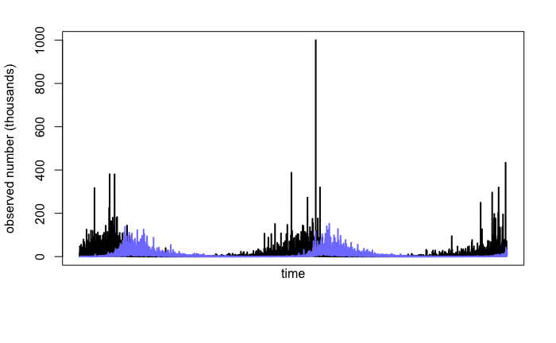

```r
mtext( "time" , 1 )
```

```r
plot( z[,2] , type="l" , ylim=c(0,max(z[,2])) , lwd=2 , xaxt="n" ,
      ylab="population number (thousands)" , xlab="" )
lines( z[,1] , col=rangi2 , lwd=2 )
```

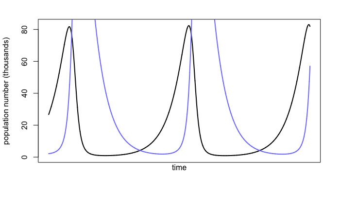

```r
mtext( "time" , 1 )
```

let’s try 10 of these

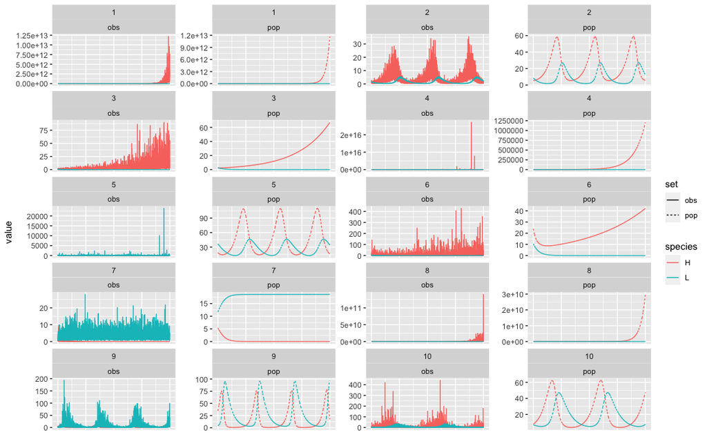

16M3, 16H1, 16H2, 16H3

(and feel free to try 16H4 and 16H5 if you have time)

## Book

```r
## R code 16.1
library(rethinking)
data(Howell1)
d <- Howell1

# scale observed variables
d$w <- d$weight / mean(d$weight)
d$h <- d$height / mean(d$height)

## R code 16.2
m16.1 <- ulam(
    alist(
        w ~ dlnorm( mu , sigma ),
        exp(mu) <- 3.141593 * k * p^2 * h^3,
        p ~ beta( 2 , 18 ),
        k ~ exponential( 0.5 ),
        sigma ~ exponential( 1 )
    ), data=d , chains=4 , cores=4 )
```

```r
precis(m16.1)
```

```r
pairs(m16.1)
```

```r
## R code 16.3
h_seq <- seq( from=0 , to=max(d$h) , length.out=30 )
w_sim <- sim( m16.1 , data=list(h=h_seq) )
mu_mean <- apply( w_sim , 2 , mean )
w_CI <- apply( w_sim , 2 , PI )
plot( d$h , d$w , xlim=c(0,max(d$h)) , ylim=c(0,max(d$w)) , col=rangi2 ,
      lwd=2 , xlab="height (scaled)" , ylab="weight (scaled)" )
lines( h_seq , mu_mean )
shade( w_CI , h_seq )
```

```r
x <- seq(0,10,.01)
plot(x,dlnorm(x))
plot(x,log(dlnorm(x)))
plot(log(x),log(dlnorm(x)))
```

```r
## R code 16.4
library(rethinking)
data(Boxes)
precis(Boxes)

## R code 16.5
table( Boxes$y ) / length( Boxes$y )
```

```r
## R code 16.6
set.seed(7)
N <- 30 # number of children

# half are random
# sample from 1,2,3 at random for each
y1 <- sample( 1:3 , size=N/2 , replace=TRUE )

# half follow majority
y2 <- rep( 2 , N/2 )

# combine and shuffle y1 and y2
y <- sample( c(y1,y2) )

# count the 2s
sum(y==2)/N
```

```r
## R code 16.7
data(Boxes_model)
cat(Boxes_model)
```

```r
## R code 16.8
# prep data
dat_list <- list(
    N = nrow(Boxes),
    y = Boxes$y,
    majority_first = Boxes$majority_first )

# run the sampler
m16.2 <- stan( model_code=Boxes_model , data=dat_list , chains=3 , cores=3 )

# show marginal posterior for p
p_labels <- c("1 Majority","2 Minority","3 Maverick","4 Random","5 Follow First")
plot( precis(m16.2,2) , labels=p_labels )
```

```r
## R code 16.8 rnndomized
# prep data
dat_list <- list(
    N = nrow(Boxes),
    y = sample(1:3, size=nrow(Boxes), replace = TRUE),
    majority_first = Boxes$majority_first )

# run the sampler
m16.2 <- stan( model_code=Boxes_model , data=dat_list , chains=3 , cores=3 )

# show marginal posterior for p
p_labels <- c("1 Majority","2 Minority","3 Maverick","4 Random","5 Follow First")
plot( precis(m16.2,2) , labels=p_labels )
```

```r
## R code 16.9
library(rethinking)
data(Panda_nuts)
```

```r
## R code 16.10
N <- 1e4
phi <- rlnorm( N , log(1) , 0.1 )
k <- rlnorm( N , log(2), 0.25 )
theta <- rlnorm( N , log(5) , 0.25 )

# relative grow curve
plot( NULL , xlim=c(0,1.5) , ylim=c(0,1) , xaxt="n" , xlab="age" ,
      ylab="body mass" )
at <- c(0,0.25,0.5,0.75,1,1.25,1.5)
axis( 1 , at=at , labels=round(at*max(Panda_nuts$age)) )
for ( i in 1:20 ) curve( (1-exp(-k[i]*x)) , add=TRUE , col=grau() , lwd=1.5 )

# implied rate of nut opening curve
plot( NULL , xlim=c(0,1.5) , ylim=c(0,1.2) , xaxt="n" , xlab="age" ,
      ylab="nuts per second" )
at <- c(0,0.25,0.5,0.75,1,1.25,1.5)
axis( 1 , at=at , labels=round(at*max(Panda_nuts$age)) )
for ( i in 1:20 ) curve( phi[i]*(1-exp(-k[i]*x))^theta[i] , add=TRUE ,
                         col=grau() , lwd=1.5 )
```

```r
dens(phi)
dens(k)
dens(theta)
```

```r
## R code 16.11
dat_list <- list(
    n = as.integer( Panda_nuts$nuts_opened ),
    age = Panda_nuts$age / max(Panda_nuts$age),
    seconds = Panda_nuts$seconds )

m16.4 <- ulam(
    alist(
        n ~ poisson( lambda ),
        lambda <- seconds*phi*(1-exp(-k*age))^theta,
        phi ~ lognormal( log(1) , 0.1 ),
        k ~ lognormal( log(2) , 0.25 ),
        theta ~ lognormal( log(5) , 0.25 )
    ), data=dat_list , chains=4 )
```

```r
precis(m16.4)
```

```r
## R code 16.11 JM
dat_list <- list(
    n = as.integer( Panda_nuts$nuts_opened ),
    age = Panda_nuts$age ,
    seconds = Panda_nuts$seconds )

m16.4JM <- ulam(
    alist(
        n ~ poisson( lambda ),
        lambda <- seconds*phi*(1-exp(-k*age))^theta,
        phi ~ lognormal( log(1) , 0.1 ),
        k ~ lognormal( log(2) , 0.25 ),
        theta ~ lognormal( log(5) , 0.25 )
    ), data=dat_list , chains=4 )
```

```r
precis(m16.4JM)
```

```r
## R code 16.12
post <- extract.samples(m16.4)
plot( NULL , xlim=c(0,1) , ylim=c(0,1.5) , xlab="age" ,
      ylab="nuts per second" , xaxt="n" )
at <- c(0,0.25,0.5,0.75,1,1.25,1.5)
axis( 1 , at=at , labels=round(at*max(Panda_nuts$age)) )

# raw data
pts <- dat_list$n / dat_list$seconds
point_size <- normalize( dat_list$seconds )
points( jitter(dat_list$age) , pts , col=rangi2 , lwd=2 , cex=point_size*3 )

# 30 posterior curves
for ( i in 1:30 ) with( post ,
                        curve( phi[i]*(1-exp(-k[i]*x))^theta[i] , add=TRUE , col=grau() ) )
```

```r
## R code 16.13
library(rethinking)
data(Lynx_Hare)
plot( 1:21 , Lynx_Hare[,3] , ylim=c(0,90) , xlab="year" ,
      ylab="thousands of pelts" , xaxt="n" , type="l" , lwd=1.5 )
at <- c(1,11,21)
axis( 1 , at=at , labels=Lynx_Hare$Year[at] )
lines( 1:21 , Lynx_Hare[,2] , lwd=1.5 , col=rangi2 )
points( 1:21 , Lynx_Hare[,3] , bg="black" , col="white" , pch=21 , cex=1.4 )
points( 1:21 , Lynx_Hare[,2] , bg=rangi2 , col="white" , pch=21 , cex=1.4 )
text( 17 , 80 , "Lepus" , pos=2 )
text( 19 , 50 , "Lynx" , pos=2 , col=rangi2 )
```

```r
## R code 16.14
sim_lynx_hare <- function( n_steps , init , theta , dt=0.002 ) {
    L <- rep(NA,n_steps)
    H <- rep(NA,n_steps)
    L[1] <- init[1]
    H[1] <- init[2]
    for ( i in 2:n_steps ) {
        H[i] <- H[i-1] + dt*H[i-1]*( theta[1] - theta[2]*L[i-1] )
        L[i] <- L[i-1] + dt*L[i-1]*( theta[3]*H[i-1] - theta[4] )
    }
    return( cbind(L,H) )
}
```

```r
## R code 16.15
theta <- c( 0.5 , 0.05 , 0.025 , 0.5 )
z <- sim_lynx_hare( 1e4 , as.numeric(Lynx_Hare[1,2:3]) , theta )

plot( z[,2] , type="l" , ylim=c(0,max(z[,2])) , lwd=2 , xaxt="n" ,
      ylab="number (thousands)" , xlab="" )
lines( z[,1] , col=rangi2 , lwd=2 )
mtext( "time" , 1 )
```

```r
## R code 16.16
N <- 1e4
Ht <- 1e4
p <- rbeta(N,2,18)
h <- rbinom( N , size=Ht , prob=p )
h <- round( h/1000 , 2 )
dens( h , xlab="thousand of pelts" , lwd=2 )
```

```r
## R code 16.17
data(Lynx_Hare_model)
cat(Lynx_Hare_model)
```

```r
## R code 16.18
dat_list <- list(
    N = nrow(Lynx_Hare),
    pelts = Lynx_Hare[,2:3] )

m16.5 <- stan( model_code=Lynx_Hare_model , data=dat_list , chains=3 , cores=3 ,
               control=list( adapt_delta=0.95 ) )
```

```r
## R code 16.19
post <- extract.samples(m16.5)
pelts <- dat_list$pelts
plot( 1:21 , pelts[,2] , pch=16 , ylim=c(0,120) , xlab="year" ,
      ylab="thousands of pelts" , xaxt="n" )
at <- c(1,11,21)
axis( 1 , at=at , labels=Lynx_Hare$Year[at] )
points( 1:21 , pelts[,1] , col=rangi2 , pch=16 )
# 21 time series from posterior
for ( s in 1:21 ) {
    lines( 1:21 , post$pelts_pred[s,,2] , col=col.alpha("black",0.2) , lwd=2 )
    lines( 1:21 , post$pelts_pred[s,,1] , col=col.alpha(rangi2,0.3) , lwd=2 )
}
# text labels
text( 17 , 90 , "Lepus" , pos=2 )
text( 19 , 50 , "Lynx" , pos=2 , col=rangi2 )
```

```r
## R code 16.20
plot( NULL , pch=16 , xlim=c(1,21) , ylim=c(0,500) , xlab="year" ,
      ylab="thousands of animals" , xaxt="n" )
at <- c(1,11,21)
axis( 1 , at=at , labels=Lynx_Hare$Year[at] )
for ( s in 1:21 ) {
    lines( 1:21 , post$pop[s,,2] , col=col.alpha("black",0.2) , lwd=2 )
    lines( 1:21 , post$pop[s,,1] , col=col.alpha(rangi2,0.4) , lwd=2 )
}
```

```r
## R code 16.21
data(Lynx_Hare)
dat_ar1 <- list(
    L = Lynx_Hare$Lynx[2:21],
    L_lag1 = Lynx_Hare$Lynx[1:20],
    H = Lynx_Hare$Hare[2:21],
    H_lag1 = Lynx_Hare$Hare[1:20] )
```